# Introduction à l’analyse de données

Economie Ecologique

Simon Jean

simon.jean@agroparistech.fr

AgroParisTech - CIRED - PSAE

# Introduction

- Le but de cette séance est de vous familiariser avec quelques outils modernes que les économistes *doivent* maîtriser : pour celles et ceux qui auraient besoin d’un rafraichissement sur les structures de données de base (vecteurs, matrices, dataframes) voir le [cours de Laurent Rouvière](https://lrouviere.github.io/TUTO_R/objetsR.html)
- On utilisera le logiciel R, et on va :
  - Apprendre un workflow utile pour tous vos projets
  - Importer et nettoyer des données
  - Faire des statistiques descriptives (plus ou moins compliquées)
  - Un peu de cartographie
- De façon générale, l’intelligence artificielle (ChatGPT, Claude etc) sont hyper performants : n’hésitez pas vous en aider, à apprendre avec

## R

- Langage de programmation libre et open source interprété, datant des années 1990, développé par R. Ihaka et R. Gentleman
- Destiné à l’analyse statistique et à la visualisation de données
- Langage populaire parmi les statisticiens, chercheurs et data-scientists
- Utilise des packages c’est à dire des collections de fonctions qui permettent de faire une grande variété de choses
- Pour s’en servir: on installe R, puis un Integrated Development Environment (IDE) comme RStudio par exemple
  - Pour ceux qui ne l’auraient pas : [installer R et RStudio](https://posit.co/download/rstudio-desktop/)

## Projets sur R

- Premièrement, on crée un projet. Ils permettent de :
  - Regrouper tout le code au sein d’une architecture reproductible
  - Créer des environnements afin d’avoir un code *reproductible*, gérant les dépendances entre projets et dans le temps
  - Partager rapidement et facilement le code entre différents utilisateurs
  - Suivre dans le temps via le contrôle de version, notamment en utilisant Git (ce sera pour une autre fois)
- Il faut donc créer un nouveau projet:
  - Créez un dossier facilement identifiable sur votre bureau, nommé `Projets`
  - Ouvrez `R Studio`, et cliquez sur `File > New Project`
  - Puis `New Directory > New Project` puis nommez le `analyse_economie_ecologique` ou ce que vous préférez comme titre de projet
  - Vous avez créé un projet!

## Reproducibilité

- On parle de reproducibilité à plusieurs niveaux dans l’analyse scientifique :
  - Reproducibilité computationelle : pouvoir répliquer exactement les résultats
  - Reproducibilité empirique : refaire les tests d’une autre manière
  - Reproducibilité conceptuelle : retrouver les mêmes résultats avec de nouvelles données
- Celle ci est en crise : beaucoup de résultats en science ne sont pas réplicables
- Pas simplement la recherche académique, toute production visant à être étayée et partagée doit viser la reproducibilité

## Comment rendre la recherche reproductible?

1. Une architecture claire et organisée par projets:
   - Des fichiers séparés pour les données brutes, traitées et les scripts
2. Contrôle de version : on ne verra pas ça ensemble
3. Management des dépendances :
   - Créer des environnements pour vérouiller les bibliothèques
   - Documenter toutes les dépendances
   - Partager les fichiers `.lock` avec les collaborateurs
4. Pipeline de données :
   - Ne jamais modifier les fichiers de données brutes
   - Créer des scripts séparés pour le nettoyage et l’analyse
   - Construire des fonctions modulaires et réutilisables - c’est un art
   - Documenter la transformation des données
5. Documentation :
   - Maintenez des `README` clairs et exhaustifs
   - Commentez le code
   - Générez des rapports automatisés avec les fichiers `markdown`
6. Automatisation :
   - Utilisez des chemins relatifs : le package `here()`
   - Créez des rapports reproductibles

## Architecture

Le but est d’avoir une architecture claire, pour que vos résultats puissent être reproduits, avec :

- Les scripts : c’est le texte, le code qui sera exécuté
- Les données : brutes ou nettoyées, ou additionelles de sources extérieures
- Les résultats: figures, tableaux etc
- La documentation : les rapports, ou encore un fichier qui s’appelle le `Readme.md`, qui détaille le projet, les instructions d’utilisation etc.
- Pour commencer, vous allez aller sur la [page Github du cours](https://github.com/sim-jean/intro_data_analysis), pour télécharger les scripts qui vont nous permettre de créer l’architecture, et mener les analyses.
  - Prenez simplement les fichiers en `.md` et enregistrez les dans `scripts/`
  - Téléchargez également le fichier `baie_somme_2025.xlsx`

[figure not shown]

- Dans la console de R, vous allez d’abord créer le dossier `scripts`, afin d’y enregistrer ces scripts que vous aurez téléchargé :
- On va utiliser le package `here` qui facilite le traitement des adresses des fichiers au sein de votre ordinateur
- Puis on va créer les dossiers

```r
if(!("here" %in% installed.packages())){ # Vérifie si le package est déja installé
  install.packages("here") # L'installe si besoin
}

library(here) # Charge la bibliothèque

if(!dir.exists(here("scripts"))){ # Vérifie si le chemin existe déja
  dir.create(here("scripts"))
}

print(paste(here("scripts"), " est créé"))
```

```
[1] "C:/Users/jean/OneDrive/Desktop/Teaching/AgroParisTech/Master EEET/M1/Economie écologique/intro_data_analysis/scripts  est créé"
```

- Utilisez le script `01_Setup.md`
  - On utilise un format spécifique, le markdown, qui mélange le texte, le code Latex si besoin, ainsi que l’analyse de données dans des blocs de code
  - Vous pouvez l’exporter en cliquant sur `Render` et avoir un document sous format `hmtl`, ou `pdf` que vous pouvez partager
- On veut créer l’architecture suivante

```
Projet/
├── R/                   # Contient tous les scripts R du projet
│   ├── 01_utilities.rmd # Script d'importation des données
│   ├── 02_cleaning.rmd    # Script de nettoyage des données
│   ├── 03_analysis.rmd    # Script d'analyse des données
│   └── 04_visualisation.rmd # Script pour les graphiques et visualisations
├── data/                # Contient les fichiers de données brutes et traitées
│   ├── raw/             # Données brutes
│   │   └── data1.csv    # Exemple de fichier de données brutes
│   │   └── README.txt   # Texte explicatif des données
│   ├── processed/       # Données nettoyées et traitées
│   │   └── data_clean.csv
│   └── external/        # Données externes ou partagées (ex. bases de données publiques)
│       └── source.csv
├── results/             # Résultats des analyses (sorties, graphiques, tableaux)
│   ├── figures/         # Graphiques générés (png, pdf, etc.)
│   │   └── plot1.png
│   └── tables/          # Tables générées (ex. CSV ou LaTeX)
│       └── table1.csv
├── docs/                 # Documentation du projet (rapports, instructions, etc.)
│   ├── report.pdf       # Rapport principal du projet
│   └── README.md        # Explication du projet, instructions d'utilisation
├── .gitignore           # Fichier pour ignorer certains fichiers dans un dépôt Git (si applicable)
├── renv.lock            # Fichier verrouillant les versions des packages (géré par renv)
├── renv/                # Dossier contenant l'environnement isolé géré par renv
└── README.md            # Fichier d'accueil du projet pour décrire brièvement de quoi il s'agit
```

On utilise le code suivant :

```r
if(!dir.exists(here("data"))){ # Vérifie si le chemin existe déja
  dir.create(here("data"))
  dir.create(here("data", "raw")) # Crée des dossiers à l'intérieur de \data
  dir.create(here("data", "processed"))
  dir.create(here("data", "external"))

  dir.create(here("results"))
  dir.create(here("results", "figure"))
  dir.create(here("results", "tables"))

  dir.create(here("docs"))
}

print("Architecture à jour")
```

```
[1] "Architecture à jour"
```

## Packages et environnements

Ensuite, on va télécharger et installer des packages utiles :

- Le package `rmarkdown` et `knitr` pour effectivement avoir des documents en markdown qui soient pris en compte par R
- La collection de package `tidyverse` qui contient entre autres :
  - `tidyr` et `dplyr` : sont essentiels pour la manipulation de données de base ainsi que le recodage, la création de nouvelles variables, le filtrage etc
  - `gpplot2` et `ggsci`: le package de référence pour la data visualisation et des `themes()` (styles) de référence dans la littérature scientifique
- `readxl` : pour lire des données en format `.xlsx`
- `magrittr`: un package qui permet d’utiliser l’opérateur pipe `%>%`, qui permet de connecter les opérations entre elles, simplifiant le processus de $g(h(x))$ à `x %>% h() %>% g()`
- `stringr` et `stringdist`: pour traiter les données textuelles
- `renv` : on va créer un environnement, permettant de travailler avec les bons outils
- Des packages dont je vous expliquerai ensuite la nécessité pour les analyses statistiques et cartographiques que l’on va mener comme `factoextra`, `factoMineR`, `sf` et `sp`

## Environnement

- Clé pour rendre le travail reproductible :
  - Les versions des packages sont stockées
  - Quand l’environnement est partagé, tout le monde travail avec les mêmes packages, permettant la reproducibilité entre personnes et dans le temps
- Chaque projet peut avoir des versions de package différentes sans encombre

```r
# I. Installer le package renv s'il ne l'est pas déja dans l'environnement global
if(!("renv" %in% installed.packages())){
  install.packages("renv")
}

library(renv)

# II. Activation ou création de l'environnement

if(!dir.exists(here("renv"))){ # si l'environnement n'existe pas  déja (ce qui est mon cas)
  renv::init()               # sinon, on l'initialise
}else{
  #renv::activate()
}
```

```r
# III. Installer chaque package


packages_to_install = c("rmarkdown", "knitr", "tidyverse", "readxl", "openxlsx",
                        "magrittr", "factoextra", "FactoMineR", "sf", "sp", "here", "ggsci")

install_and_load <- function(packages){
  for (pkg in packages){
    if(!(pkg %in% installed.packages())){# Pour chaque package de la liste
    renv::install(pkg)       # installe le cas échéant
    }
    library(pkg, character.only = TRUE)           # Puis le charge
  }
}

install_and_load(packages_to_install)

renv::snapshot()
```

```
- The lockfile is already up to date.
```

# Data cleaning

## Chargement des données

- On va maintenant pouvoir charger les données
  - Enregistrez le fichier `baie_somme_2025.xlsx` dans `data\raw`
  - Ouvrez `scripts/02_cleaning.Rmd`

```r
data_ = readxl::read_xlsx(here("data", "raw", "baie_somme_2025.xlsx"))

head(data_)
```

```
# A tibble: 6 × 16
  Horodateur          `Lieu de l'entretien` `Jour de l'entretien`
  <dttm>              <chr>                 <dttm>
1 2025-01-13 14:38:18 Hourdel               2025-01-13 00:00:00
2 2025-01-13 14:48:03 Hourdel               2025-01-13 00:00:00
3 2025-01-13 15:06:42 <NA>                  NA
4 2025-01-13 15:13:54 <NA>                  NA
5 2025-01-13 15:26:11 <NA>                  NA
6 2025-01-13 15:34:16 Pointe                2025-01-13 00:00:00
# ℹ 13 more variables: `Heure de l'entretien` <dttm>,
#   `Caractéristique de la personne interviewée` <chr>,
#   `Age approximatif` <chr>,
#   `Lieu de résidence de la personne interviewée` <chr>,
#   `Activité de loisir de la personne interrogée :` <chr>,
#   `Activité professionnelle de la personne interrogée :` <chr>,
#   `Q1 : Connaissez-vous le nom des espèces de phoques qui sont présentes dans la baie de Somme ? (Si oui préciser les espèces, Si ne sait pas, donner les deux noms des espèces (phoque gris et phoque veau-marin))` <chr>, …
```

## Diagnostic

- On va regarder déja la structure des données et le taux de complétude des données
- On va ensuite regarder comment standardiser les noms de variables, les réponses aux questions (souvent imparfaites), assigner le bon format etc.

## Exploration des variables

```
 POSIXct[1:218], format: "2025-01-13 14:38:18" "2025-01-13 14:48:03" "2025-01-13 15:06:42" ...
```

```
 chr [1:218] "Employé" "Employé" "Retraite" "Retraité" "Retraite" ...
```

```
 chr [1:218] "Il faut laisser la nature évoluer librement, La surfréquentation peut générer des dérangements pour la nature" ...
```

```
 [1] "Horodateur"
 [2] "Lieu de l'entretien"
 [3] "Jour de l'entretien"
 [4] "Heure de l'entretien"
 [5] "Caractéristique de la personne interviewée"
 [6] "Age approximatif"
 [7] "Lieu de résidence de la personne interviewée"
 [8] "Activité de loisir de la personne interrogée :"
 [9] "Activité professionnelle de la personne interrogée :"
[10] "Q1 : Connaissez-vous le nom des espèces de phoques qui sont présentes dans la baie de Somme ? (Si oui préciser les espèces, Si ne sait pas, donner les deux noms des espèces (phoque gris et phoque veau-marin))"
[11] "Q2 : Savez-vous combien il y a de phoque gris et de phoque veau-marin dans la baie de Somme ?"
[12] "Q3 : Avez-vous déjà vu des phoques dans la baie"
[13] "Q4 : Est-ce qu’ils vous dérangent dans vos activités de loisir ou professionnelle ? Pourquoi ?"
[14] "Q5 : A quoi assimilez vous le phoque (2 choix max) ?"
[15] "Q6 :  Pouvez-vous me dire si vous êtes d’accord avec les affirmations suivantes (cocher lorsque accord) ?"
[16] "Avez-vous des suggestions concernant cette question des phoques dans la Baie de Somme ?"
```

- On a plusieurs informations sur les formats :
  - `POSIT`: données temporelles formatées en date
  - `chr` : données “character” i.e. données textuelles, sans notion d’ordre etc
- Pour certaines variables on va vouloir passer de données textuelles à des données catégorielles, c’est à dire des données textuelles avec différents niveaux
- Pour certaines questions à choix multiple, les réponses sont collées entre elles :
  - Il va falloir réfléchir à comment les extraire
  - Et à comment les exploiter
- Les noms de colonnes ne sont pas pratiques à utiliser : on va les renommer

```r
colnames(data_) = c("date", "lieu", "jour", "heure", "genre",
                    "classe_age", "residence", "loisir", "profession",
                    "q1_nom_phoques", "q2_pop_phoques", "q3_vue_phoques",
                    "q4_dérangement", "q5_classe_phoque", "q6_avis", "q7_divers")
```

## Nettoyer les lieux

```r
unique(data_$residence)
```

```
 [1] "Hauts de Seine(92)"
 [2] "Abbeville"
 [3] NA
 [4] "Nancy"
 [5] "Beauvais"
 [6] "Essonne"
 [7] "Drancourt"
 [8] "Pas d'ici"
 [9] "Crotoy"
[10] "Saint Valery sur Somme"
[11] "Dunkersue"
[12] "Franciere (somme)"
[13] "Saint Valery"
[14] "Vers saint valery"
[15] "Le crotoy"
```

[output cut: 74 more lines]

```r
unique(data_$lieu)
```

```
 [1] "Hourdel"                NA                       "Pointe"
 [4] "Saint Valéry sur Somme" "Le Crotoy"              "Amiens"
 [7] "Le Tréport"             "Trépot"                 "Le Treport"
[10] "Tréport"                "Treport"                "Le treport"
[13] "Le tréport"             "treport"                "Abbeville"
[16] "Abeville"               "L'Oise"                 "Cayeux-sur-mer"
[19] "Cayeux"                 "POINTE DU HOURDEL"      "Berck"
[22] "Berck sur mer"          "Berck-sur-mer"
```

- Pas mal de choses qui se ressemblent mais ne sont pas pareilles : `Saint Valéry`, `St Valery`, `Saint Valery sur Somme` etc
  - On va essayer de se débarasser de la ponctuation et des lettres majuscules
  - Corriger les fautes d’orthographe
  - Se débarasser des imprécisions ou choses non nécessaires (depuis 2 ans, (Somme)) etc
- Tout en conservant toutes les données : on ne remplace jamais la donnée initiale!!
- On le fait à la main ici, mais des approches plus structurées existent:
  - Distance entre les groupes nominaux : combien faut il changer de caractères (`stringdist`)
  - Matching avec des bases géographiques : on le fera plus tard pour les coordonnées géographiques

Q1 : Complétez pour St Valery

```r
remplacement_lieux = function(x_){
#' Standardisation des noms de lieux
#'
#' Cette fonction normalise les noms de lieux en les mettant en minuscules,
#' en supprimant les accents et les articles, puis en les remplaçant par des
#' noms standardisés selon une liste prédéfinie.
#'
#' @param x_ Une chaîne de caractères représentant un nom de lieu (potentiellement mal orthographié ou mal formaté).
#' @return Une chaîne de caractères avec le nom de lieu standardisé. Si aucun correspondance n'est trouvée, la fonction retourne l'entrée originale.

  x = str_to_lower(x_) # On met tout en minuscule
  x = x %>%
    gsub("\\ble\\b", "", .)%>% # On enlève "le" à l'aide d'une expression régulière (regex)
    gsub("é", "e", .)          # On enlève également les accents aigus et graves

  # Après inspection, on fait ce qu'on peut pour remplacer ensemble les zones géographiques

  if(x %in% c(' treport', 'trepot', 'treport', "treport depuis 2 ans")){
    return('Le Tréport')
  }else if(x %in% c('abbeville', 'abeville', "abbevilel", "abbville")){
    return('Abbeville')
  }else if(x %in% c(' crotoy', 'le crotoy', 'crotoy')){
    return('Le Crotoy')
  }else if(x %in% c("berck-sur-mer", "berck sur mer", "berck")){
    return('Berck-sur-mer')
  }else if(x %in% c('cayeux-sur-mer', 'cayeux', "cayeux sur mer")){
    return('Cayeux-sur-mer')
  }else if(x %in% c('saint valery sur somme',"saimt valery","saint-valery-sur-somme",
                    "saint valéry", "saint valery", "st valery", "vers saint valery" ,
                    "saint-valerie-sur-somme")){
    return('Saint-Valery-sur-Somme')
  }else if(x %in% c('hourdel', 'pointe', 'pointe du hourdel')){
    return("Pointe du Hourdel")
  }else if(x %in% c("feuquieres en vimeu",  "feuquieres - en - vimeu" )){
    return('Feuquières-en-Vimeu')
  }else if(x %in% c('noyelles sur mer', 'noyelle sur mer')){
    return('Noyelles-sur-mer')
  }else if(x %in% c("amiens",  "amiens / berck"  )){
    return("Amiens")
  }else if(x %in% c('lancheres', 'lanchere', 'lancher', "lanchéres")){
    return('Lanchéres')
  }else if(x %in% c('arlay a 5km du crotoy')){
    return('Arlay')
  }else if(x %in% c("fauquembergues (résidence secondaire)")){
    return('Fauquembergues')
  }else if(x %in% c("villers cotterets(02600)" )){
    return('Villers Cotterets')
  }else if( x %in% c("franciere (somme)"  )){
    return('Francières')
  }else if( x %in% c("hauts de seine(92)")){
    return('Hauts de Seine')
  }else if( x %in% c("Saint-Riquier", "Saint-riquier", "saint-riquier")){
    return('Saint-Riquier')
  }else if( x %in% c("pendé", "pende")){
    return('Pendé')
  }else if( x %in% c("arras")){
    return('Arras')
  }else if( x %in% c("dunkersue")){
    return('Dunkerque')
  }

  else{
    return(x_)
  }
}
```

```r
data_ = data_ %>%
  mutate(clean_lieu = sapply(lieu, remplacement_lieux)) # On applique la fonction remplacement à chaque lieu
                                                  # et sapply renvoie un vecteur qui est assigné à
                                                  # une nouvelle variable
unique(data_$clean_lieux)
```

Q2 : enregistrez la nouvelle data avec dplyr, sapply

[output not shown]

[output cut: 46 more lines]

## Variable catégorielle ordonnée : l’âge

On a classé la population par groupes d’âge. L’usage de variables `factor` permet d’avoir des variables catégorielles ordonnées, que l’on peut représenter sur un axe ordonné en précisant les niveaux (`levels`)

Q3: transformez l’âge en variable facteur

Si vous ne savez pas comment vous y prendre, utilisez `?nom_de_la_fonction` pour trouver de l’aide

```r
data_$classe_age = factor(data_$classe_age,
                          levels = c("<20 ans","20-35 ans","35-50 ans",
                                     "50-65 ans", ">65 ans"))
```

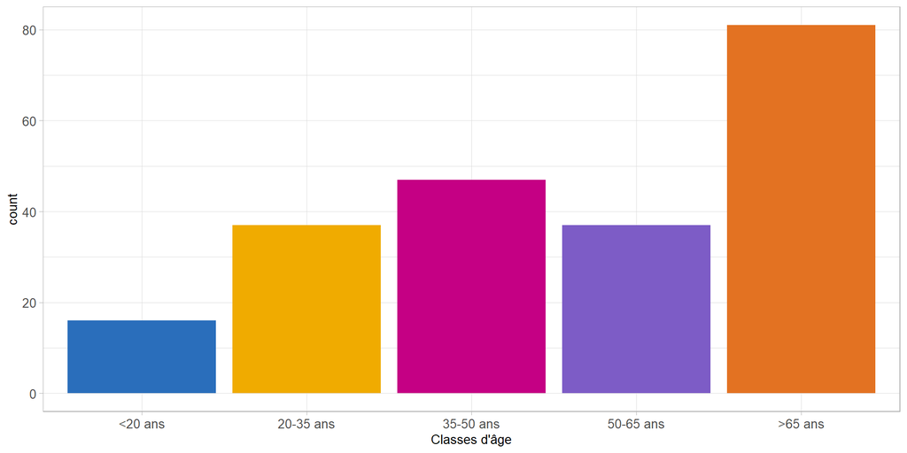

## Variables continues tronquées : population des phoques

- Variable *continue* : on va surement devoir *discretiser*
- Qui est limitée à 0
- Avec beaucoup de non réponse

Challenges techniques :

- Transformer la variable `chr` en variable `int`
- On va utiliser la population totale

Q4 : Tabulez la population des phoques!

```
                 100 - 200                      100.0
                         1                          5
                    1000.0                      120.0
                         4                          1
                    1300.0                  1500-3000
                         1                          1
                      20.0                    200-300
                         1                          1
200 gris et 400 veau marin                      200.0
                         1                          2
                    2000.0                    20000.0
                         2                          1
                     300.0                     3000.0
                         4                          1
                     400.0                      450.0
                         3                          2
           50 000- 100 000                      500.0
                         1                          5
                   50000.0                      600.0
                         1                          2
                   600/700                800 environ
                         1                          1
                     800.0                        Bcp
                         1                          2
                  Beaucoup              Beaucoup trop
                         1                          1
          Entre 500 et 800                        Nln
                         1                          1
                        Nn                         No
                         2                          1
                        Nô                        non
                         1                          1
                       Non                   Non - 50
                       112                          1
                 Non (100)                   Non (20)
                         2                          1
                 Non (200)                 Non (2000)
                         2                          1
                  Non (30)                  Non (300)
                         1                          1
```

[output cut: 11 more lines]

```
                         1                          1
             Oui - 300-400                   Oui - 50
                         1                          1
                Oui (3000)                  Oui (800)
                         1                          1
                  Oui 1000                  Oui(1000)
                         1                          1
           OUI, 500 et 200     Pas du tout (beaucoup)
                         1                          1
                   Pas mal               Plus de 1500
                         1                          1
        Quelques centaines          Quelques milliers
                         1                          1
          Quelques uns, 25               Une centaine
                         1                          1
```

On a beaucoup de réponses mixtes, il faudrait extraire les données chiffrées, les ordres de grandeur, et les réponses comme `Non` et `Oui`

```r
remplacement_phoques_1 = function(x_){
#' Cette fonction donne une indication sur la connaissance (oui ou non) de la population de phoque
#' @param x_ une chaine de caractères


  return(grepl("non", str_to_lower(x_)))
}


remplacement_phoques_population = function(x_, option = "max"){

#' Extraction et classification des nombres liés aux populations de phoques
#'
#' Cette fonction analyse une chaîne de caractères pour extraire des nombres
#' (représentant des populations de phoques) et les classifier en différentes catégories
#' (`Beaucoup`, `Centaines`, `Milliers`, `Quelques uns`, etc.).
#'
#' @param x_ Une chaîne de caractères contenant une estimation de population (peut inclure des chiffres, des mots ou des expressions variées).
#' @param option Une option définissant si l'on souhaite récupérer la valeur minimale ou maximale
#' dans le cas de plages numériques (`"min"` ou `"max"`). Par défaut `"max"`.
#' @return Une valeur numérique si un chiffre est détecté, ou une catégorie (`"Beaucoup"`, `"Centaines"`, `"Milliers"`, `"Quelques uns"`, `"Non"`, etc.).



  # Approche par regex :
  potential_number = x_ %>%
    gsub(" ", "", .)%>%
    str_extract_all(.,"\\d+\\.?\\d*")%>%
    unlist()%>%
    as.numeric()
  # On repère les chiffres :
  # \\d+ repère un chiffre ou plusieurs
  # \\.? repère un point décimal
  # \\d* prent les 0

  # Ensuite on vérifie s'il y a des "-" ou des "/"

  tiret_barre = grepl("[-/]", x_)

  # Message d'erreur si l'option n'est pas bien spécifiée
  if(!(str_to_lower(option) %in% c("min", "max"))){
    stop("Error : option is ill picked")
  }

    # Enfin, on prend les "beaucoup" en compte :

  if(x_ %in% c(startsWith(str_to_lower(x_), "beauco"),
              'Bcp', 'Non beaucoup', 'Pas du tout (beaucoup)')){
    return("Beaucoup")
  }else if(is_empty(potential_number)){
    if(startsWith(str_to_lower(x_), 'oui')){
      return('Oui')
    }else if(grepl("centai", str_to_lower(x_))){
      return('Centaines')
    }else if(grepl('milli', str_to_lower(x_))){
      return('Milliers')
    }else if(grepl('un', str_to_lower(x_))){
      return('Quelques uns')
    }else{
      return('Non')
    }
  }else{
    if(tiret_barre){
      if(length(potential_number)>1){
        if(option=='min'){
          return(min(potential_number))
        }else if(option=="max"){
          return(max(potential_number))
        }
      }else{
        return(as.numeric(potential_number))
      }
    }else{
      return(sum(as.numeric(potential_number)))
    }
  }
}
```

[output not shown]

```r
data_ = data_ %>%
  mutate(clean_pop_yes_no = sapply(q2_pop_phoques, remplacement_phoques_1),
         clean_pop_max = sapply(q2_pop_phoques, remplacement_phoques_population))

# On récupère également la distinction entre chiffrée et ordre de grandeur
chiffre_ou_non = data_%>%
  select(clean_pop_max)%>%
  pull()%>%
  as.numeric()


data_ = data_ %>%
  mutate(
    # Créer la variable numérique en convertissant les valeurs en numérique
    chiffre_num = as.numeric(clean_pop_max),

    # Remplacer les valeurs non numériques par NA
    clean_pop_phoque_chiffre = if_else(is.na(chiffre_num), NA_real_, chiffre_num),

    # Créer la variable non numérique pour les réponses textuelles
    clean_pop_phoque_non_chiffrée = if_else(is.na(clean_pop_phoque_chiffre), clean_pop_max, NA_character_)
  )
```

## Variables catégorielles ordinales : professions

```r
t(table(data_$profession))# Pour voir les fréquences
```

```
       Agence immobilier Agent public Agriculteur (à préciser) Aide à domicile
  [1,]                 1           20                        3               1

       Aide soignante Archéologue Assistante à domicile Cadre Cadre supérieur
  [1,]              1           1                     1     1               3

       Chômage Collégien Commerçant (préciser) Cuisine
  [1,]       1         1                    13       1

       Dessinateur en bureau d'étude Élève Élèves Employé Employee medical
  [1,]                             1     1      2      26                1

       Enseignante Entrepreneur indépendant Entreprise/tourisme (à préciser)
  [1,]           1                        1                                1

       Etudiant Étudiant Étudiant college Etudiante Étudiante Étudiantes
  [1,]        1        5                1         2         2          1

       Famille d'accueil Femme au foyer Foyer d’enfants Gérant de restaurant
  [1,]                 1              1               1                    1

       Infirmiere Infirmière
  [1,]          1          1

       Intermittente du spectacle + boutique d'ésortérisme Mairie
  [1,]                                                   1      1

       Maîtresse d'école Mécanicien Medical Non Ouvrier Ouvrier agricole
  [1,]                 1          1       1   1       6                1

       Pas demandé Pêcheur (préciser) Photographe Prof Professeur
  [1,]           1                  2           1    4          1

       Réceptionniste en hôtellerie Recruteur de donateurs pour association
  [1,]                            1                                       1

       Restauration/hôtellerie Retraite Retraité Retraité militaire
  [1,]                      12       37       32                  1

       Retraité pêcheurs Retraité/ avant aide soignante Retraitée Retraites
  [1,]                 1                              1         1         1

       Rien Sans Sans emploi Tabac Traducteur
  [1,]    1    1           1     1          1

       Travail avec des enfants handicapés Usine
  [1,]                                   1     2
```

On a encore des problèmes d’encodage : je vous laisse y penser

- Trouvez les dénominations en CSP les plus pertinentes
- Regroupez les personnes dans la bonne CSP en :
  - Modifiant la fonction `remplacement()`
  - Et en attribuant les CSP à une nouvelle variable

On peut utiliser un prétraitement des données et la fonction `startsWith(x, prefix)` pour rassembler tout ce qui commencerait par la même racine

Q5 : utilisez `startsWith()` pour compléter la fonction suivante et rédigez la documentation

```r
csp_questionnaire = c("Entreprise/tourisme", "Restauration/hôtellerie" , "Agriculteur (à préciser)",
                      "Pêcheur (préciser)","Commerçant (préciser)", "Agent public",
                      "Cadre supérieur", "Employé", "Ouvrier")


remplacement_professions = function(x_){

#' Classification des professions à partir d'un questionnaire
#'


  x = x_%>%
    str_to_lower()%>%
    gsub("é", "e", .)%>%
    gsub("è", "e", .)

  if(x %in% c('agriculteur (à preciser)')){
    return("Agriculteur exploitant")
  }else if(startsWith(x, "employ") | x %in% c('aide à domicile',
                                              'aide soignante', 'assistante à domicile',
                                              "famille d'accueil", "tabac", "medical",
                                              "recruteur de donateurs pour association")){
    return("Employé.e")
  }else if(x %in% c('sans', 'rien', 'sans emploi', 'chômeur','chômage', 'non', "femme au foyer")){

  # COMPLETER L'EXPRESSION

    return('Sans activité professionelle (hors retraite)')
  }else if(startsWith(x, 'retrait')){
    return('Retraité.e')
  }else if(startsWith(x, 'ouvrier') | x %in% c('mecanicien', 'usine')){
    return("Ouvrier")
  }else if(startsWith(x, 'foyer') | x %in% c("infirmiere", "maîtresse d'ecole", 'enseignante', 'professeur', 'prof', "foyer d'enfants", "travail avec des enfants handicapes")){
    return('Professions intermédiaires')
  }else if(startsWith(x, 'cadr') | startsWith(x, 'intermittente') | x %in% c('traducteur', "archeologue", "dessinateur en bureau d'etude", 'photographe', "agence immobilier") ){
    return("Cadres et professions intellectuelles supérieures")
  # Catégories du questionnaire
  }else if(x %in% c('gerant de restaurant', 'receptionniste en hôtellerie', 'restauration/hôtellerie', "cuisine")){
    return("Restauration/hôtellerie")
  }else if(startsWith(x, "entrepr") | startsWith(x, "commerçant")){
    return("Artisans, commerçants, chefs d'entreprise")
  }else if(x %in% c('agent public', 'mairie')){
    return('Agent public')
  }else{
    return(x_)
  }

}
```

```r
csp_questionnaire = c("Entreprise/tourisme", "Restauration/hôtellerie" , "Agriculteur (à préciser)", "Pêcheur (préciser)","Commerçant (préciser)", "Agent public",
                      "Cadre supérieur", "Employé", "Ouvrier")


remplacement_professions = function(x_){

#' Classification des professions à partir d'un questionnaire
#'
#' Cette fonction standardise les réponses d'un questionnaire concernant la profession des répondants
#' en les classant dans des catégories socio-professionnelles.
#'
#' @param x_ Une chaîne de caractères représentant une profession, telle qu'indiquée par un répondant.
#' @return Une chaîne de caractères correspondant à une catégorie professionnelle standardisée.

  x = x_%>%
    str_to_lower()%>%
    gsub("é", "e", .)%>%
    gsub("è", "e", .)

  if(x %in% c('agriculteur (à preciser)')){
    return("Agriculteur exploitant")
  }else if(startsWith(x, "employ") | x %in% c('aide à domicile',
                                              'aide soignante', 'assistante à domicile',
                                              "famille d'accueil", "tabac", "medical",
                                              "recruteur de donateurs pour association")){
    return("Employé.e")
  }else if((startsWith(x, "etudian") | startsWith(x, "eleve") | startsWith(x, "colleg") | x %in% c('sans', 'rien',
                                                                                                   'sans emploi', 'chômeur',
                                                                                                   'chômage', 'non', "femme au foyer"))){
    return('Sans activité professionelle (hors retraite)')
  }else if(startsWith(x, 'retrait')){
    return('Retraité.e')
  }else if(startsWith(x, 'ouvrier') | x %in% c('mecanicien', 'usine')){
    return("Ouvrier")
  }else if(startsWith(x, 'foyer') | x %in% c("infirmiere", "maîtresse d'ecole", 'enseignante', 'professeur', 'prof', "foyer d'enfants", "travail avec des enfants handicapes")){
    return('Professions intermédiaires')
  }else if(startsWith(x, 'cadr') | startsWith(x, 'intermittente') | x %in% c('traducteur', "archeologue", "dessinateur en bureau d'etude", 'photographe', "agence immobilier") ){
    return("Cadres et professions intellectuelles supérieures")
  # Catégories du questionnaire
  }else if(x %in% c('gerant de restaurant', 'receptionniste en hôtellerie', 'restauration/hôtellerie', "cuisine")){
    return("Restauration/hôtellerie")
  }else if(startsWith(x, "entrepr") | startsWith(x, "commerçant")){
    return("Artisans, commerçants, chefs d'entreprise")
  }else if(x %in% c('agent public', 'mairie')){
    return('Agent public')
  }else{
    return(x_)
  }

}
```

## Variables catégorielles nominales : nom des phoques

Ici, on va adopter la même approche par fonction de `remplacement()`

```r
table(data_$q1_nom_phoques)
```

```
                                Gris                   Gris et veau marin
                                   1                                    1
                Gris et veaux marins                             Les deux
                                   1                                    1
                                 Nln                                   Nn
                                   1                                    2
                                 Nob                                  non
                                   1                                    1
                                 Non                                  Oui
                                 136                                   47
       Oui (manque les phoques gris)                         Oui les deux
                                   1                                    2
                     Oui phoque gris OUI phoque gris et phoque veau-marin
                                   1                                    1
                   Oui plus ou moins                       Oui veau-marin
                                   1                                    1
                         Pas de tout                          Phoque gris
                                   1                                    1
                Phoque gris et blanc                Phoque veau-marin oui
                                   1                                    1
                        Phoques gris                             Touriste
                                   1                                    1
                            Vaumarin                           Veau-marin
                                   1                                    2
         Veau-marin et phoque commun                           Veau marin
                                   1                                    5
            Veau marin , phoque gris                 Veau marin et phoque
                                   1                                    1
        Veaux-marins et phoques gris
                                   1
```

On va prendre comme réponses possible : `oui`, `non`, `Partiel: veau marin` et `Partiel: phoque gris`

Q6 - Faites une fonction de remplacement pour les phoques

```r
remplacement_phoques_noms = function(x){

#' Standardisation des réponses sur les espèces de phoques observées
#'
#' Cette fonction catégorise les réponses concernant la présence des espèces de phoques
#' (veau-marin et phoque gris) en les regroupant dans des classes standardisées.
#'
#' @param x Une chaîne de caractères correspondant à une réponse du questionnaire sur les phoques observés.
#' @return Une chaîne de caractères standardisée : `"Oui"`, `"Non"`, `"Partiel : Veau-marin"`, `"Partiel : Phoque gris"`, ou la réponse initiale si elle ne correspond à aucune catégorie.

  if(x %in% c('Veaux-marins et phoques gris', 'Veau marin , phoque gris', 'OUI phoque gris et phoque veau-marin',
              'Gris et veaux marins', 'Veau marin et phoque', 'Les deux', 'Oui', 'Gris et veau marin',
              'Gris et veaux marins', "Les deux ", 'Oui les deux')){
    return('Oui')
  }else if(x %in% c('Non', 'nn', 'Nob', 'Nln', 'Non', 'Nn',
                    'non', 'Pas de tout', 'Touriste', 'Oui plus ou moins')){
    return('Non')
  }else if(x %in% c('Oui (manque les phoques gris)', 'Veau-marin',
                    'Phoque veau-marin oui', 'Vaumarin', 'Veau marin',
                    'Veau-marin et phoque commun', 'Veau-marin', 'Oui veau-marin')){
    return("partiel : Veau-marin")
  }else if(x %in% c('Gris', 'Oui phoque gris', 'Phoque gris et blanc', 'Phoques gris', 'Phoque gris')){
    return('Partiel : phoque gris')
  }else{
    return(x)
  }
}

data_ = data_ %>%
  mutate(clean_noms_phoques = sapply(q1_nom_phoques, remplacement_phoques_noms))
```

## Variables catégorielles nominales multiples: avis sur les phoques

La différence ici, c’est que plusieurs choix sont possibles

```r
# Trouver toutes les phrases possibles

phrases_ = c() # Initier un stock de phrases vide

for(row_ in 1:nrow(data_)){ # Pour chaque individu
  candidate_ =  unlist(# On enlève la structure de liste
    strsplit(as.character(data_[row_, "q6_avis"]), # qui résulte de la séparation de chaque réponse
             ", ") # autour de la virgule
    )
  for(element_ in candidate_){ # On regarde pour chaque phrase cnadidate
    if(!(element_ %in% phrases_)){ # Si elle a déja été dite
      phrases_ = c(phrases_, element_) # Sinon, on l'ajoute
    }
  }
}
# Imprimer les 15 premières phrases
phrases_[1:15]
```

```
 [1] "Il faut laisser la nature évoluer librement"
 [2] "La surfréquentation peut générer des dérangements pour la nature"
 [3] "Les conflits entre les humains et les phoques augmentent"
 [4] "Les phoques font partie du patrimoine du territoire"
 [5] "Il y a trop de phoques veau-marin"
 [6] "Il y a trop de phoques gris"
 [7] "Il ne faut pas que le nombre de phoque augmente plus"
 [8] "Les phoques mangent trop de poissons"
 [9] "Les phoques représentent une opportunité économique pour le territoire"
[10] "Les phoques représentent une menace économique pour le territoire"
[11] "Il faudrait un groupe de travail local sur les interactions avec les phoques"
[12] "Il faudrait plus de panneaux d’informations sur les phoques"
[13] "Il faudrait des barrières pour empêcher de déranger les phoques"
[14] "Il faudrait un centre d’information sur les phoques"
[15] "Visites guide nature m"
```

On a des problèmes de remplissage du questionnaire!

On va récupérer les choix du questionnaire

- Ensuite, on fait ce qu’on appelle du one hot encoding, c’est à dire que l’on:
  - Transforme chaque affirmation en une variable
  - Qui prend la valeur 0 si absente, 1 si présente
  - Permet de numériser les variables *catégorielles* sans imposer d’ordre

```r
data_ = data_ %>%
  mutate(ID = seq(1:nrow(data_))) # On donne un identifiant à chaque individu statistique

# On crée une table d'occurence vide
table_occurrences <- matrix(0,
                            nrow = nrow(data_),
                            ncol = length(phrases_possibles),
                            dimnames = list(seq(1:nrow(data_)),
                                             phrases_possibles)) # Nomme les dimensions

# Remplir le tableau avec les occurrences
for (i in 1:nrow(data_)) {
  phrases_ = unlist(                            # On enlève la structure de liste
    strsplit(as.character(data_[i, "q6_avis"]), # qui résulte de la séparation de chaque réponse
             ", ")                              # autour de la virgule
    )
  for (phrase in phrases_) {                    # Pour chaque phrase exprimée,
    if (phrase %in% phrases_possibles) {        # si elle est dite,
      table_occurrences[i, phrase] <- table_occurrences[i, phrase] + 1 # on encode
    }
  }
}
```

Q7 : Convertir la matrice en dataframe pour une meilleure lisibilité

```r
# Convertir la matrice en dataframe pour une meilleure lisibilité

table_occurrences_df <- as.data.frame(table_occurrences)

colnames(table_occurrences_df) = paste0("q_clean_", c('nature_libre','surfréquentation', 'conflits',
                                   'patrimoine','trop_veau', 'trop_gris','pas_plus_phoques',
                                   'trop_poisson','opportunité_économique', 'menace_économique',
                                   'groupe_travail', 'panneaux',
                                   'barrières', 'centre_information', 'menace_tradition'))

table_occurrences_df = table_occurrences_df%>%
  mutate('ID' = seq(1, nrow(table_occurrences_df)))
```

## Variables catégorielles nominales multiples : questions sur les phoques

On fait la même chose pour la question sur les phoques

```r
phrases_ = c() # Initier un stock de phrases vide

for(row_ in 1:nrow(data_)){ # Pour chaque individu
  candidate_ =  unlist(# On enlève la structure de liste
    strsplit(as.character(data_[row_, "q5_classe_phoque"]), # qui résulte de la séparation de chaque réponse
             ", ") # autour de la virgule
    )
  for(element_ in candidate_){ # On regarde pour chaque phrase cnadidate
    if(!(element_ %in% phrases_)){ # Si elle a déja été dite
      phrases_ = c(phrases_, element_) # Sinon, on l'ajoute
    }
  }
}

phrases_possibles = c("Un animal sympathique et paisible", "Une espèce invasive et nuisible",
                      "Un concurrent pour les activités humaines", "Une espèce menacée",
                      "Un prédateur supérieur"
                      )

data_ = data_ %>%
  mutate(identifier = seq(1:nrow(data_))) # On donne un identifiant à chaque individu statistique


# On crée une table d'occurence vide
table_occurrences <- matrix(0,
                            nrow = nrow(data_),
                            ncol = length(phrases_possibles),
                             dimnames = list(seq(1:nrow(data_)),
                                             phrases_possibles)) # Pour stocker un identifiant

# Remplir le tableau avec les occurrences
for (i in 1:nrow(data_)) {
  phrases_ = unlist(# On enlève la structure de liste
    strsplit(as.character(data_[i, "q5_classe_phoque"]), # qui résulte de la séparation de chaque réponse
             ", ") # autour de la virgule
    )
  for (phrase in phrases_) {
    if (phrase %in% phrases_possibles) { # si elle est dite,
      table_occurrences[i, phrase] <- table_occurrences[i, phrase] + 1
    }
  }
}
```

## Variables catégorielles nominales multiples : loisirs

- Il y a beaucoup trop de réponses uniques (64)
- Il faut revenir aux résultats du questionnaire, et traiter notamment les réponses collées (variables catégorielles multiples)
- On refait du one hot encoding

```r
# I. On doit cleaner les données pour bien pouvoir les isoler : on supprime ce qu'il se passe entre parenthèse pour pouvoir séparer les entités par l'usage de la virgule
data_loc = data_ %>%
  select(loisir)

data_loc= data_loc %>%
  mutate(loisir_easy = gsub("\\s*\\(.*?\\)", '', loisir))%>%
  mutate(loisir_easy = gsub(" ", "", loisir_easy))%>%
  mutate(loisir_easy = str_to_lower(loisir_easy))



phrases_possibles = c("Pêche):", "Chasse", "Voile", "vélo", "natation",
                      "Planceàvoile", "Paddle",  "Kayak/canoë", "Kitesurf", "Equitation", "Wingfoil",
                      "Promenade", "Marche", "Naturaliste")
phrases_possibles = str_to_lower(phrases_possibles)

# II. On crée une table d'occurence vide
table_occurrences <- matrix(0,
                            nrow = nrow(data_),
                            ncol = length(phrases_possibles) +1, # On ajoute une case pour prendre en compte les cas "Autres"
                            dimnames = list(seq(1:nrow(data_)),
                                             c(phrases_possibles, "Autre"))) # Pour stocker un identifiant




#III. Remplir le tableau avec les occurrences
for (i in 1:nrow(data_)) {
  phrases_ =
    unlist(# On enlève la structure de liste
    strsplit(as.character(data_loc[i, "loisir_easy"]), # qui résulte de la séparation de chaque réponse
             ",") # autour de la virgule
    )
  for (phrase in phrases_) {
    if (phrase %in% phrases_possibles) { # si elle est dite,
      table_occurrences[i, phrase] <- table_occurrences[i, phrase] + 1
    }else{
      table_occurrences[i, "Autre"] = table_occurrences[i, "Autre"] +1
    }
  }
}
```

## Synthèse et nettoyage final

On merge tout et on sélectionne les données propres :

Q8 : utilisez le pipe operator (%>%) pour sélectionner les colonnes de la `full_data` et récupérer les colonnes qui ont le nom `clean` avec `grepl`

On sauvegarde les données en `.xlsx` mais les formats de référence sont plutot:

- `.csv`
- pour des données plus larges `.json`
- `.parquet`
- ou encore les `data.tables` pour les format de matrices avec beaucoup de `0` suivant le one hot encoding de larges données (accélère également leur écriture et leur ouverture)

```r
data_clean = full_data %>%
  select(c('date', 'genre', 'classe_age',    # Les données déja propres
           colnames(full_data)[full_data %>%         # Les colonnes que l'on a nommé clean
                                 colnames() %>%      # car nettoyées!
                                 grepl("clean", .)]
           )
         )

colnames(data_clean) = gsub("clean_", "", colnames(data_clean))

write.xlsx(data_clean, here("data", "processed", "data_cleaned.xlsx"))
```

## Documentation

- Créez un fichier `.txt` ou `.md` qui détaille les données *brutes* et enregistrez le dans `/docs/README_rawdata.txt`
- Créez un fichier `.txt` ou `.md` qui détaille les transformations appliquées aux données et les fonctions utilisées, et enregistrez le dans `/docs/README_datacleaning.txt`
  - Faites un dictionnaire de variables: dansl’idéal, il faut le faire, mais je l’ai fait pour vous (enfin, `ClaudeAI` l’a fait à ma place)
    - Nom des variables; Descriptions; Type de variables ;Unité de mesure ;Valeurs possibles ;Valeurs manquantes ;Source des données; Commentaires et remarques
- Idéalement, il faudrait refaire tout cela pour réplication de sorte que :
  - Updatez le script `fonctions.R` avec les fonctions que l’on a utilisées : elles ne sont pas encore très modulaires ou beaucoup réutilisables, mais c’est un premier pas.
  - Appelez le script `fonctions.R` avec `source(here("scripts", "fonctions.R"))` en début de script et utilisez les fonctions

# Analyse de données

## Quelles analyses mener?

1. Etude des valeurs manquantes
2. Etude des distributions des variables clés
3. Analyse de corrélation entre variables
4. Analyse multivariées

```
- The lockfile is already up to date.
```

## Analyses simples

Pour cela, on va utiliser la bibliothèque `ggplot2` (Grammar of Graphics) qui prend les éléments suivants :

- Les données (`data`)
- Les “aesthetics” (`aes()`) : comment représenter les variables, qui est en abscisse (`x=`), en ordonnée (`y=`), en couleur (`color=`)
- La géométrie (`geom()`): le type de graphique
- Une variété d’éléments de style :
  - `scale_color_`, `scale_fill` pour les couleurs
  - `theme()` pour les axes, polices, tailles, couleur de fond
- On peut également représenter sur différents panels avec les fonctions `facet_`
- Marche au mieux lorsque les données sont sous le format `tidy`: une variable par colonne, une observation par ligne
  - On utilise parfois `pivot_longer()` pour transformer des données “larges” en “longues”, pour tout représenter d’un coup

## Les variables démographiques

- Code
- Graph

```r
custom_theme = function(){
  theme_minimal() +  # Base theme
  theme(
    axis.text.x = element_text(angle = 45, hjust = 1),  # Rotate x-axis labels by 45 degrees
    legend.position = "bottom"
  )
}

p = data_ %>%
  select(c('genre', 'classe_age','date', 'professions', 'lieu')) %>%
  pivot_longer( - date,
               values_to = 'values',
               names_to = 'names')%>%
    ggplot(aes(x=values))+
    geom_histogram(stat="count")+
    facet_grid(~names,  scales = "free")+
  custom_theme()
```

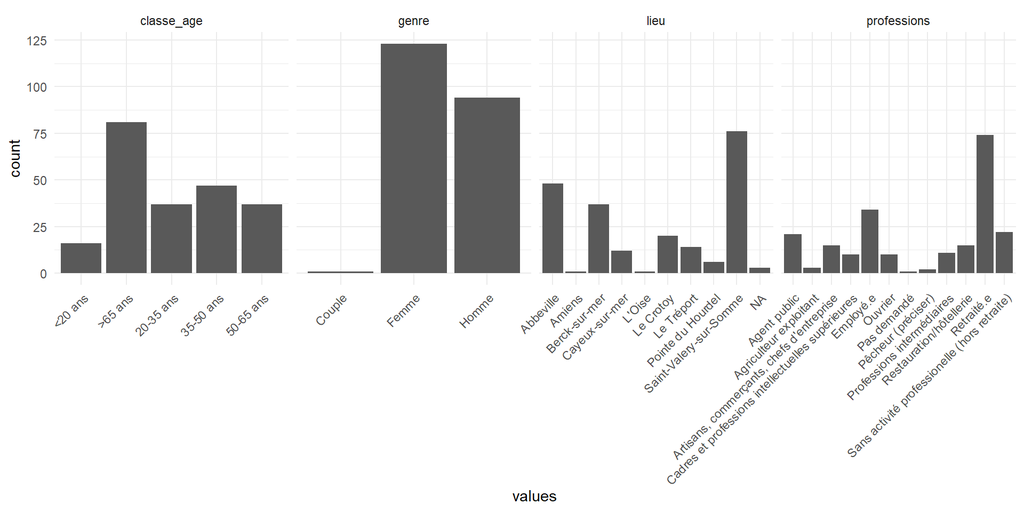

Q1 : Ecrivez le code pour plotter la variable `classe_age` avec `ggplot`

- Code et indices
- Plot

Indices :

- les datas sont elles `tidy` avec une seule variable?
- Pensez à utiliser la caractéristique `stat = count`

```r
p = data_ %>%
  ggplot(aes(x = classe_age))+
  geom_bar(stat= 'count')
```

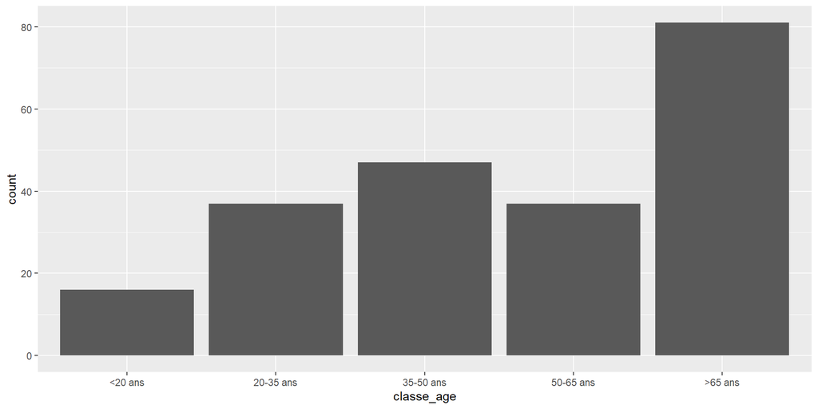

Ce n’est pas très joli, ni modulaire : on va écrire une fonction

- Code
- Age
- Professions
- Lieux

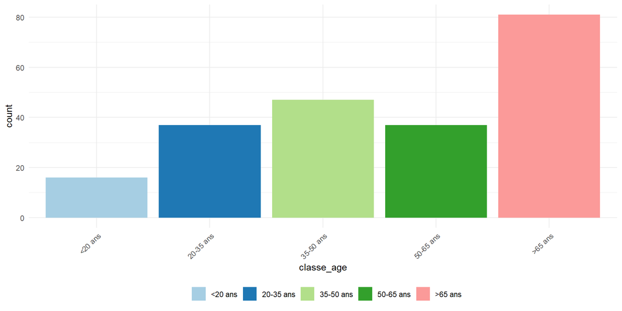

```r
plot_distribution("classe_age")
```

```r
ggsave(here('results','figure', paste0("classe_age",'.jpg')), width = 25, height = 18, units = 'cm')
```

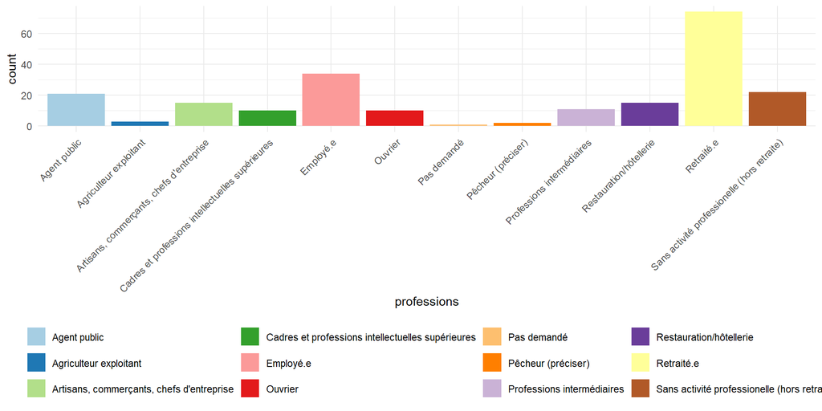

```r
plot_distribution("professions")
```

```r
ggsave(here('results','figure', paste0("professions",'.jpg')), width = 25, height = 18, units = 'cm')
```

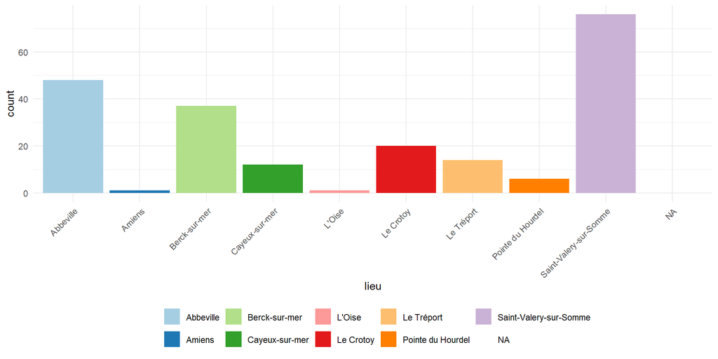

```r
plot_distribution("lieu")
```

```r
ggsave(here('results','figure', paste0("lieu",'.jpg')), width = 25, height = 18, units = 'cm')
```

## Population de phoques : noms

```r
plot_distribution("noms_phoques")
```

```r
ggsave(here('results','figure', paste0("noms_phoques",'.jpg')), width = 25, height = 18, units = 'cm')
```

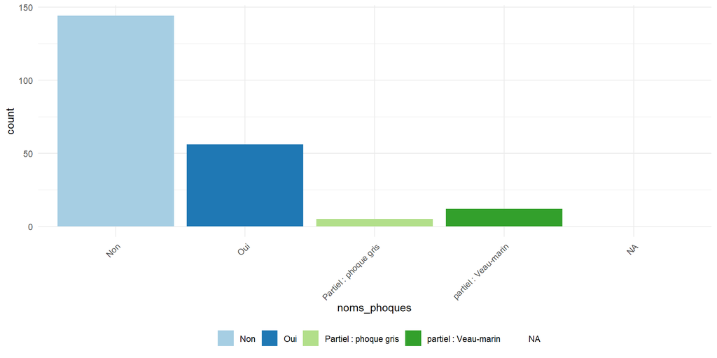

## Population de phoques

```r
plot_distribution("pop_phoque_chiffre")
```

```r
ggsave(here('results','figure', paste0("pop_phoque_chiffre",'.jpg')), width = 25, height = 18, units = 'cm')
```

[figure not shown]

- Phoques paisibles
- Invasifs et nuisibles
- Concurrents
- Menacés
- Prédateurs

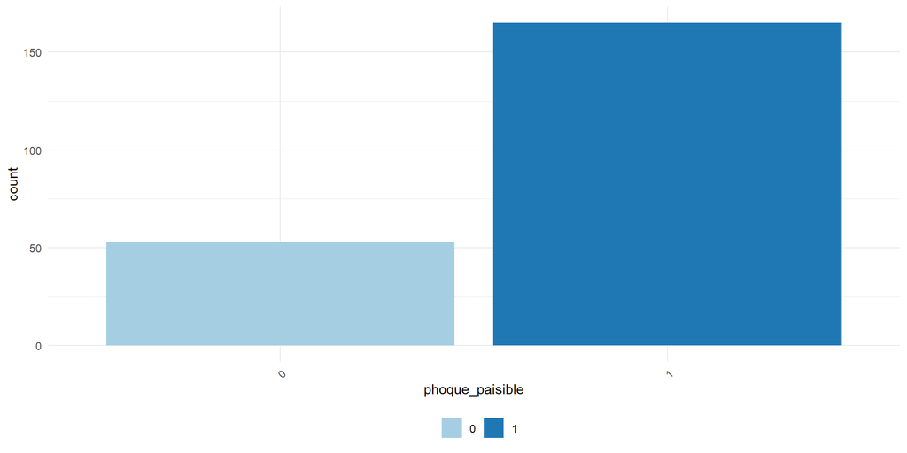

```r
plot_distribution("phoque_paisible")
```

```r
ggsave(here('results','figure', paste0("phoque_paisible",'.jpg')), width = 25, height = 18, units = 'cm')
```

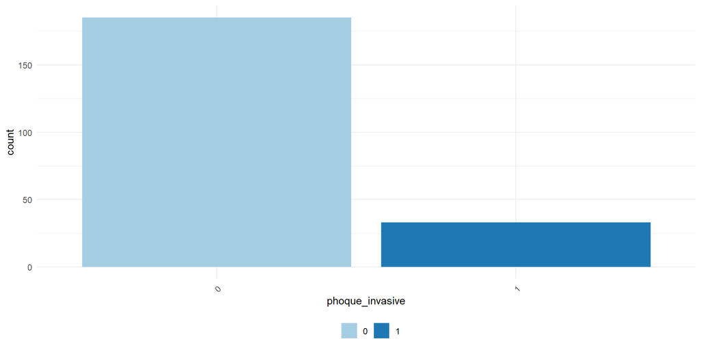

```r
plot_distribution("phoque_invasive")
```

```r
ggsave(here('results','figure', paste0("phoque_invasive",'.jpg')), width = 25, height = 18, units = 'cm')
```

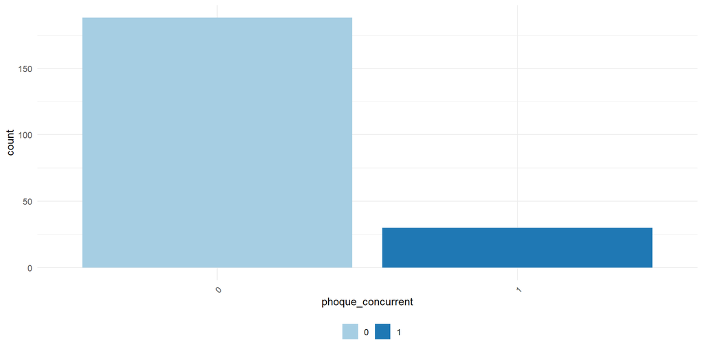

```r
plot_distribution("phoque_concurrent")
```

```r
ggsave(here('results','figure', paste0("phoque_concurrent",'.jpg')), width = 25, height = 18, units = 'cm')
```

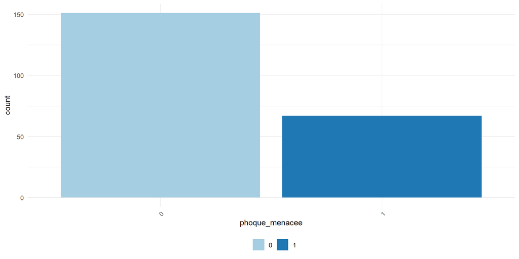

```r
plot_distribution("phoque_menacee")
```

```r
ggsave(here('results','figure', paste0("phoque_menacee",'.jpg')), width = 25, height = 18, units = 'cm')
```

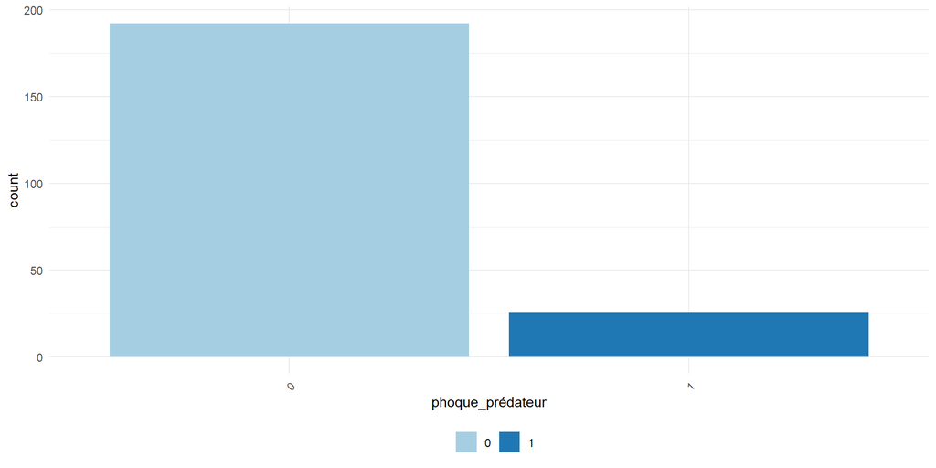

```r
plot_distribution("phoque_prédateur")
```

```r
ggsave(here('results','figure', paste0("phoque_prédateur",'.jpg')), width = 25, height = 18, units = 'cm')
```

## Analyse bivariée

On cherche la répartition de notre échantillon entre classes d’âge et différente caractéristiques :

- Code
- Graphique

```r
p = data_ %>%
ggplot(aes(x = classe_age, fill = professions)) +
  geom_bar(position = "fill") +  # Normalized proportions
  theme_minimal()+
  scale_fill_brewer(palette = "Paired")
```

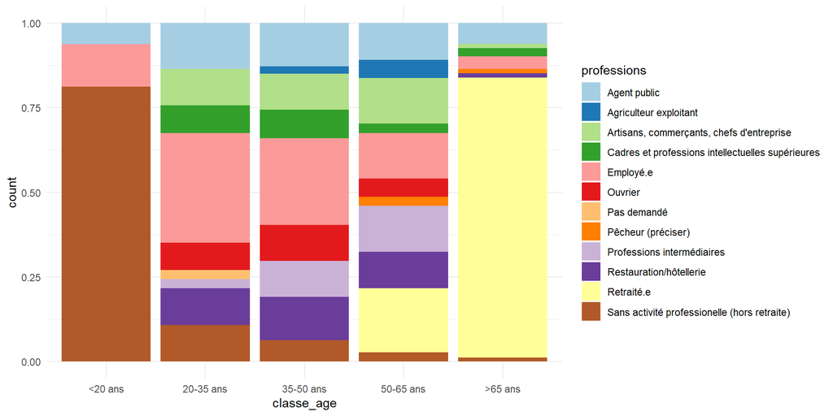

## Analyse bivariée : phoques paisible et nature sauvage

Q2 : plottez la correlation entre `phoque_paisible` et `q_nature_libre`

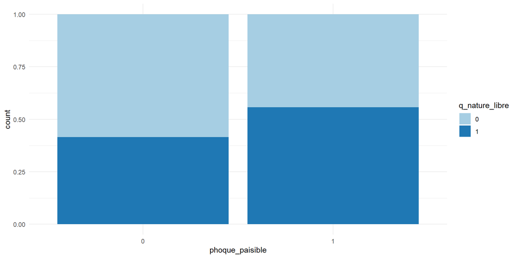

```r
data_ %>%
  ggplot(aes(x = phoque_paisible, fill = q_nature_libre)) +
  geom_bar(position = "fill") +  # Normalized proportions
  theme_minimal()+
  scale_fill_brewer(palette = "Paired")
```

## Analyse bivariée : phoques paisible et connaissance des phoques

Q3 : plottez la correlation entre `phoque_paisible` et `pop_yes_no`

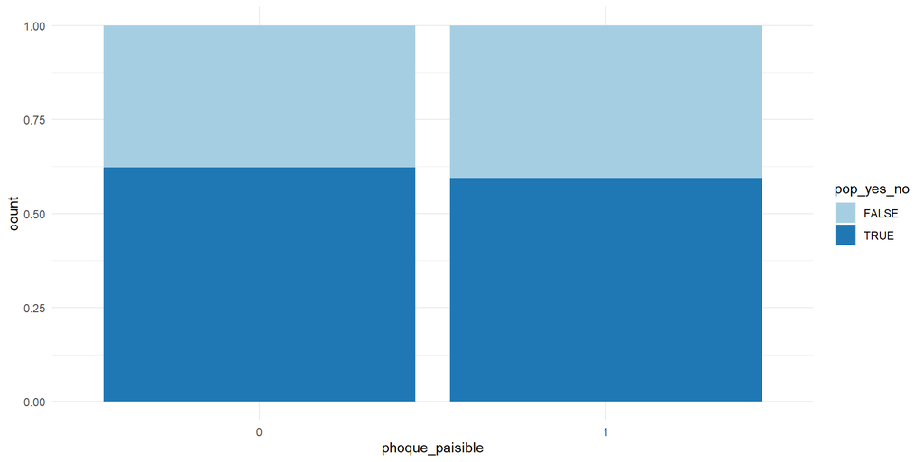

```r
data_ %>%
  ggplot(aes(x = phoque_paisible, fill = pop_yes_no)) +
  geom_bar(position = "fill") +  # Normalized proportions
  theme_minimal()+
  scale_fill_brewer(palette = "Paired")
```

## Analyses multivariées : global

- Code
- Heatmap de toutes les variables

```r
correlation_matrix = cor(data_ %>%
                           select(to_factor_vect)%>%
                           select(- c('wingfoil'))%>%
                           mutate(across(everything(), as.numeric)),
                         method = 'pearson')


# On efface la diagonale (corrélation de 1) et on garde seulement un triangle pour éviter la redondance
diag(correlation_matrix) = NA

# Convert matrix to long format for ggplot
cor_long = reshape2::melt(correlation_matrix)

p = ggplot(cor_long, aes(Var1, Var2, fill = value)) +
  geom_tile() +
  scale_fill_gradient2(low = "blue", mid = "white", high = "red", midpoint = 0) +
  labs(title = "Correlation Heatmap of One-Hot Encoded Variables",
       x = " ",
       y = " ",
       fill = "Correlation") +
  theme_minimal() +
  theme(axis.text.x = element_text(angle = 45, hjust = 1))
```

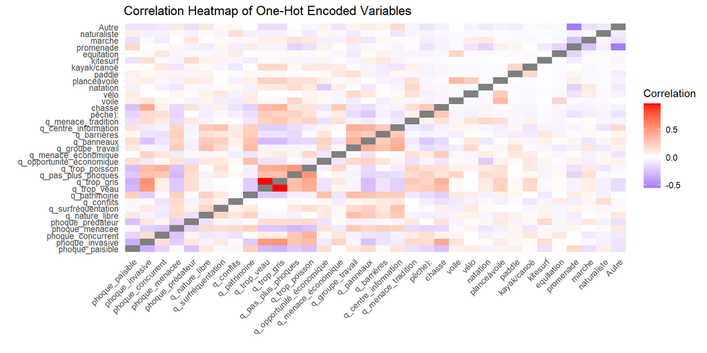

## Analyse multivariée : restreinte

- Code
- Graph

On va essayer de restreindre un peu l’analyse : Q4 : prenez un sous ensemble de variables, comme les caractéristiques des phoques et les réponses aux questions et faites une heatmap

```r
correlation_matrix = cor(data_ %>%
                           select(colnames(data_)[startsWith(colnames(data_), "q_")])%>%
                           mutate(across(everything(), as.numeric)),
                         method = 'pearson')

diag(correlation_matrix) = NA

# Convert matrix to long format for ggplot
cor_long = reshape2::melt(correlation_matrix)
```

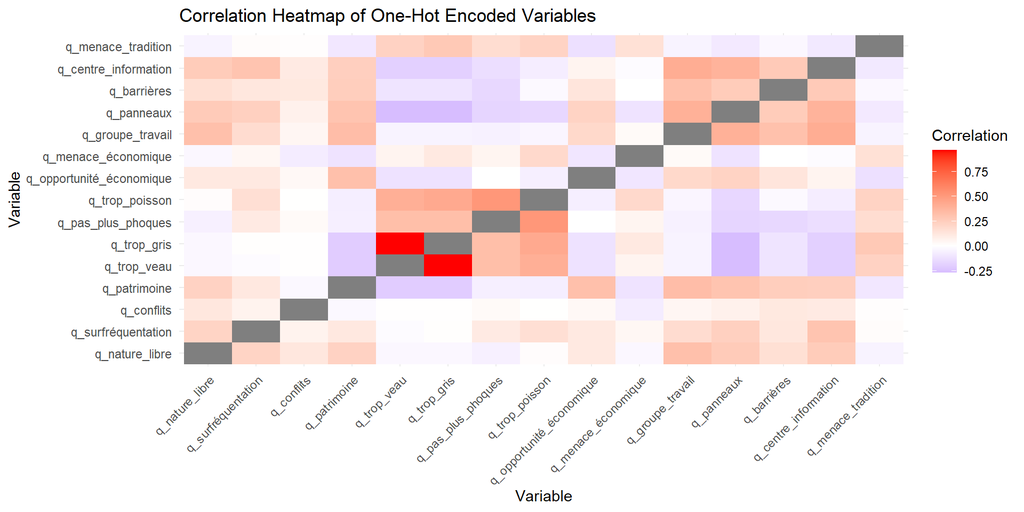

[figure not shown]

# Analyse par correspondance multiple

Technique d’analyse multivariées pour identifier la structure d’un espace de grande dimension

## Origine et développement

- Jean-Paul Benzécri (années 1960) :
  - Pionnier de l’analyse des correspondances, il développe l’Analyse des Correspondances Simples (ACS) pour représenter graphiquement la structure des tableaux de contingence.
  - Nécessité de visualiser les relations entre catégories dans des enquêtes sociales, marketing, etc.
  - Extension vers l’Analyse des Correspondances Multiples (ACM)
  - Adaptation de l’ACS pour traiter simultanément plusieurs variables qualitatives, en combinant plusieurs tableaux de contingence dans une matrice globale.
- Harold Hotelling (années 1930-1940) :
  - Pionnier de l’Analyse en Composantes Principales (ACP), il formalise la réduction de dimensionnalité pour des variables quantitatives.
  - Introduit l’idée de décomposition en valeurs propres, qui vise à extraire des axes expliquant la plus grande part de la variance.
- Théorie de l’information et géométrie
  - L’inertie (ou dispersion) dans les données est mesurée de manière similaire à la variance en ACP, ce qui permet de comparer et de représenter les structures des données.

## Intuition mathématique – De la géométrie à la décomposition

- Principe de base : représentation géométrique
  - Chaque individu est représenté par un point dans un espace de dimension élevée, chaque axe correspondant à une modalité (catégorie).
  - Objectif : trouver un espace de dimension réduite qui capture l’essentiel des relations entre modalités et individus
- Mesure de la dispersion :l’inertie
  - Inertie totale : analogue à la variance en ACP, elle mesure la dispersion totale des points par rapport au centre.
  - Chaque modalité contribue à cette inertie selon sa fréquence et son écart par rapport à l’attendu en cas d’indépendance.
- Décomposition en valeurs singulières (SVD)
  - Inspirée par l’ACP de Hotelling, la SVD permet de décomposer la matrice normalisée en axes factoriels orthogonaux.
  - La SVD « fait pivoter » l’espace initial pour révéler les directions (axes) où la dispersion (l’information) est maximale.
  - Les axes sélectionnés expliquent successivement des parts décroissantes de l’inertie totale.

Appendix

## Fonctionnement pas à pas – De la donnée brute à l’interprétation

- Préparation des données : construction d’un tableau binaire :
  - Chaque individu est décrit par des réponses qualitatives, transformées en indicateurs (1 ou 0) pour chaque modalité.
- Normalisation et calcul des distances
  - Utilisation de la distance du khi-deux, adaptée aux données qualitatives, pour mesurer la similitude entre profils.
  - Pondération des modalités selon leur fréquence pour équilibrer leur influence.
- Décomposition via SVD
  - La matrice normalisée est décomposée en composantes grâce à la SVD, qui découle directement des idées de réduction de dimensionnalité portées par l’ACP de Hotelling.
  - Chaque axe factoriel est associé à une valeur propre qui quantifie la part d’inertie expliquée.
- Projection et interprétation
  - Projection simultanée des individus et des modalités sur les axes factoriels.
  - Les points proches indiquent des profils similaires.
  - Les axes traduisent des tendances ou oppositions sous-jacentes (ex. profils traditionnels vs. profils modernes).

## Idée générale

- On minimise la distance du khi-deux intra-classe : les modalités proches doivent rester proches
- On maximise la dispersion entre groupes distincts: les modalités et individus différents doivent être bien séparés sur les axes factoriels.

## Mise en pratique

- Il faut préparer les données: on ne va pas tout garder
- Par ailleurs, la structure de nos questions n’est pas parfaite pour utiliser l’ACM :
  - Fait pour quand plusieurs niveaux d’une même question sont mutuellement exclusifs
  - Nous, on a autorisé 2 ou 5 réponses par question(s)
  - On n’a pas exactement la même structure, donc la distance du khi-deux risque d’être un peu modifiée
  - On pourrait modifier les réponses et les pondérer par le nombre de réponses
- Malgré ces problèmes, on va illustrer la méthode : on réfléchira ensuite à la meilleure manière
- Pour cela on utilise les bibliothèques `FactoMineR` et `factoextra`

```r
library(FactoMineR)
library(factoextra)

# I. Préparer les données : il faut que des facteurs

data_for_analysis = data_%>%
  select(c(to_factor_vect, 'genre', 'classe_age', 'pop_yes_no', 'professions', 'noms_phoques'))%>%
   mutate(across(everything(), as.factor))%>%
  drop_na()
```

## Réaliser l’ACM

- La fonction `MCA()` va :
  - Construire le tableau disjonctif complet.
    - Calculer la distance du khi-deux pour chaque individu et modalité.
    - Réaliser la décomposition en valeurs singulières qui, de manière implicite, minimise la somme des distances (c’est-à-dire l’inertie non expliquée).
- On enlève les modalités les plus corrélées

[output not shown]

```r
correlation_matrix[which(correlation_matrix>.7)]
```

```
[1] 0.9642916 0.9642916
```

```r
res.mca <- MCA(data_for_analysis%>%
                 select(-c('classe_age', 'pop_yes_no', 'professions', 'noms_phoques',
                           'q_trop_veau', 'q_pas_plus_phoques')),
               graph = FALSE)
```

## Visualiser les résultats

On va visualiser le scree plot qui montre la part de variance expliquée par chaque axe factoriel

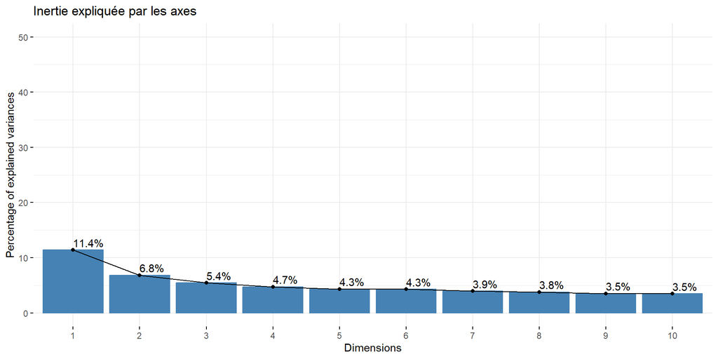

```r
fviz_screeplot(res.mca, addlabels = TRUE, ylim = c(0, 50),
               title = "Inertie expliquée par les axes")
```

## Visualisation des individus et des modalités

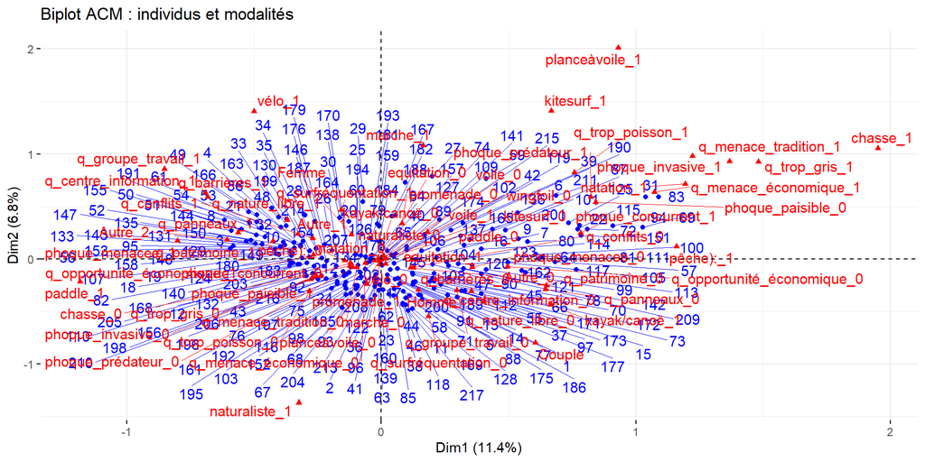

## Visualisation des modalités

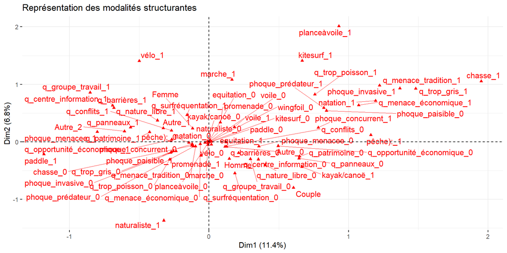

## Visualisation des modalités restreintes

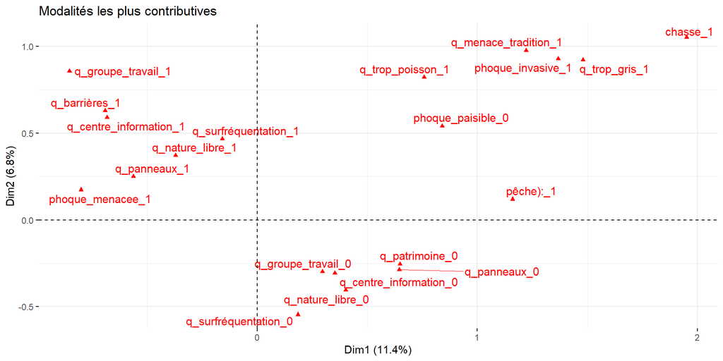

## Visualisation des modalités restreintes

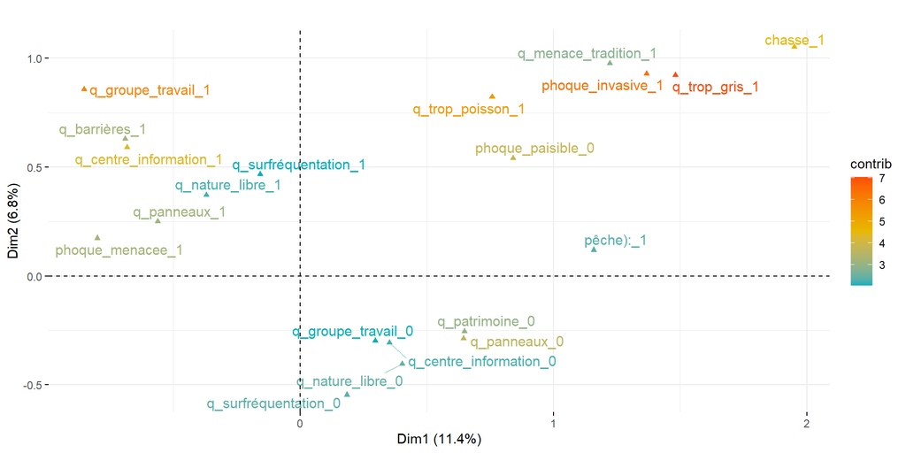

# Visualisation des individus

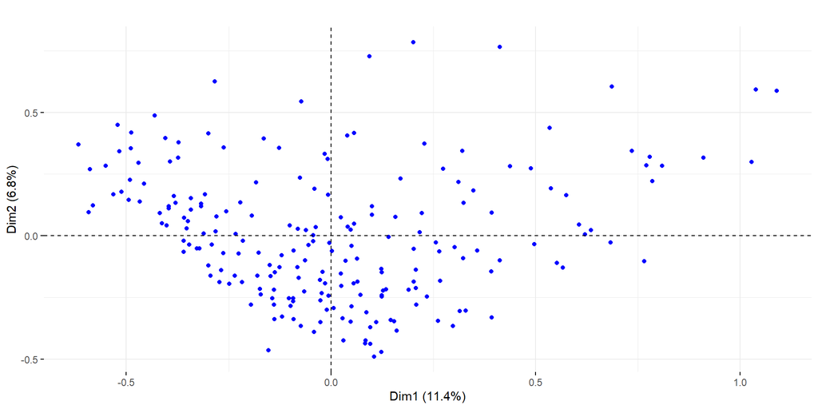

## Visualisation des individus avec classes d’age

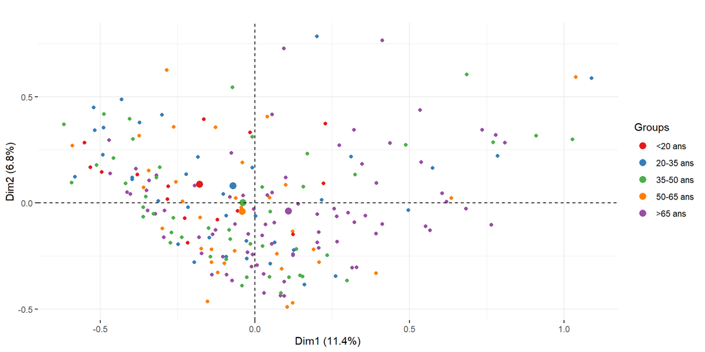

```r
palette_5 <- c("#E41A1C", "#377EB8", "#4DAF4A", "#FF7F00", "#984EA3")


fviz_mca_ind(res.mca,
             label = "none", # masquer le texte des individus
             ggtheme = theme_minimal (),
             palette = palette_5,
             habillage = data_for_analysis$classe_age,
             title=" ")
```

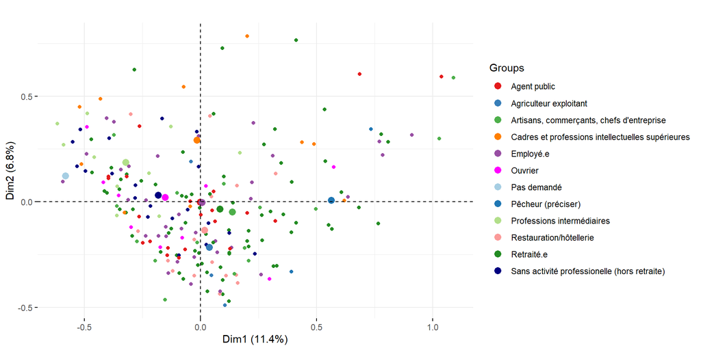

# Annexes

## Différences des méthodes géométriques

- Type de données
  - ACP : Variables quantitatives.
  - ACS : Deux variables qualitatives (tableau de contingence).
  - ACM : Plusieurs variables qualitatives (tableau disjonctif complet).
- Méthodologie sous-jacente
  - ACP : Basée sur la variance et la covariance (analyse matricielle des données numériques).
  - ACS & ACM : Basées sur les fréquences observées vs. attendues (utilisation de la distance du khi-deux) et la décomposition en valeurs singulières des tableaux normalisés.
- Objectifs analytiques
  - ACP : Réduction de dimensionnalité et interprétation des relations linéaires entre variables quantitatives.
  - ACS : Étude de l’association entre deux variables catégorielles.
  - ACM : Exploration simultanée et synthèse des relations entre plusieurs variables qualitatives.

Back to main